[deita](https://deita.eu/) [About](https://deita.eu/about.html)

# D3 · The Going-Rate Atlas

Capstone dossier · what every dish-type costs in Amsterdam, with honest ranges

Author

Dei M. Elurbe

Published

July 10, 2026

**Dossier, not the essay.** Backstage layer for technical readers; the capstone essay is the general-audience artifact. Corpus: **Snapshot · June 2026**, ~900 priced venues, roughly 4 in 10 of Amsterdam’s ~2,028 restaurants.

## The verdict

Amsterdam has a going rate for everything, and now it is written down. The Dish Atlas prices **199 dish-type cells** (146 at full confidence, 53 stabilised by pooling), covering 96% of 32,405 clean dishes: each cell gets a **typical price** (the empirical median) and a **90% range** (where 90% of that dish-type’s prices actually fall). Carpaccio as a starter: €15, range €11.50 to €23. Friet: €5.80. Bitterballen: €7.20. A dorade main: €24.50. No venue is named anywhere in the atlas; it prices dish-*types*, never restaurants.

Two design decisions carry the credibility. **Typical = the median, not the mean**, because on skewed price distributions the model’s own pooled mean misleads by 27 to 38% (the cheese-board cell reads €10.50 by geometric mean and €14.50 by median; the median is what a diner actually encounters). And **the range is the partially-pooled quantity**: big cells show their own percentiles, thin cells borrow spread from their parent cells, so a 20-dish cell cannot fake a precise range it has not earned.

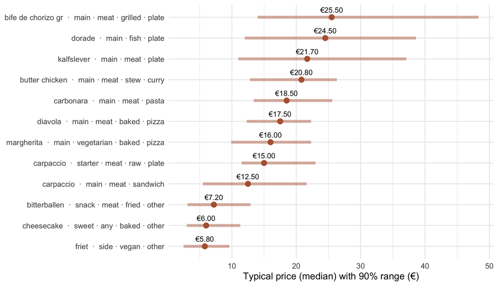

Figure 1: The going rates: typical price (dot) and 90% range (line) for twelve recognizable cells. Each label is the cell’s exemplar, the most common cleaned dish name inside it; it stands for the whole cell, not for one dish.

```r
suppressPackageStartupMessages({library(dplyr); library(ggplot2)})

atlas <- readr::read_csv("../../data/processed/dish_atlas.csv", show_col_types = FALSE)

picks <- c("side · vegan · none · other", "snack · meat · fried · other",
           "sweet · any · baked · other", "starter · meat · raw · plate",
           "main · meat · none · sandwich", "main · vegetarian · baked · pizza",
           "main · meat · baked · pizza", "main · meat · none · pasta",
           "main · meat · stew · curry", "main · meat · none · plate",
           "main · fish · none · plate", "main · meat · grilled · plate")

sel <- atlas |> filter(cell %in% picks) |>
  mutate(label = sprintf("%s  ·  %s", exemplar, sub(" · none", "", cell)))

ggplot(sel, aes(x = typical_eur, y = reorder(label, typical_eur))) +
  geom_linerange(aes(xmin = ppi_lo_eur, xmax = ppi_hi_eur),
                 colour = "#b5623f", alpha = .45, linewidth = 1.6) +
  geom_point(colour = "#b5623f", size = 2.6) +
  geom_text(aes(label = sprintf("€%.2f", typical_eur)), vjust = -0.9, size = 3) +
  labs(x = "Typical price (median) with 90% range (€)", y = NULL) +
  theme_minimal()
```

## Why the obvious approach lies, twice

**The first lie is averaging across products.** “The average dish price in Amsterdam” mixes a €2.50 side with a €49 Wagyu; it measures menu composition, nothing else. The coordinate system (dossier D1) fixes that: prices are only ever summarised *within* a cell, where dishes are the same kind of thing.

**The second lie is subtler: the mean lies even within a cell.** Dish prices are right-skewed (a long tail of expensive versions), and the model is fitted on log-prices, whose natural “average” back-transforms to the geometric mean. On skewed cells that number drifts far from what a diner actually meets. The skew check that caught this compared the model’s pooled mean against the empirical median across all confident cells: gaps up to 27 to 38%. Verdict: the model keeps the mean internally for validation, and the atlas *displays* the median. The variance components confirm the median is reliable even at 15 dishes per cell; what is unreliable in small cells is the *tails*, and that is exactly where pooling is aimed.

## The model: pooling for the tails

The fit is a nested random-effects model on log price:

$$\log(\text{price}) \sim \text{role} + (1 \mid \text{role:protein}) + (1 \mid \text{role:protein:method}) + (1 \mid \text{cell}) + (1 \mid \text{venue})$$

The nesting is the point: a cell sits inside a `role:protein:method` family, which sits inside a `role:protein` family. A thin cell (say, 18 lamb stews) does not have to estimate its price spread alone; it **borrows from its parents** in proportion to how little data it has. The displayed 90% range blends the cell’s own 5th-to-95th percentile span with the model’s pooled predictive spread, weighted by cell size (weight = n/(n+40)). Big cells are effectively empirical; thin cells are honestly wider than their own data would naively suggest. The venue random effect keeps one expensive restaurant’s menu from imprinting on a cell.

Escalating to a fully Bayesian fit (`brms`) was considered and declined, on the light-first rule: with 31,000+ dishes the residual spread is pinned, the median would not move, and the extra machinery would change nothing a reader can see. The lme4 empirical-Bayes fit runs in four seconds and reproduces to the cent.

## What it found, beyond the lookup

**Why widths differ this much: the quality ceiling.** The model cannot see undisclosed portion size or ingredient quality, and dish names differ enormously in how much they pin those down. A borrelplank has **no quality ceiling**: the same menu line covers kaasblokjes with supermarket worst and an ibérico charcuterie board, and the price honestly spans that distance. A pizza, even loaded with the most premium ingredients, still has a **pizza ceiling**: the format bounds the plate, and the city carries a reference price for it. Range width is that invisibility made visible. Wide cells are cells where the *name does not pin the product*; tight cells are cells where it does. (Seen through dossier D4’s decomposition: the ranges are its non-dish 41%, venue character plus item noise, displayed cell by cell; D4’s “ladder and the rungs” section shows the two dossiers are one set of numbers.)

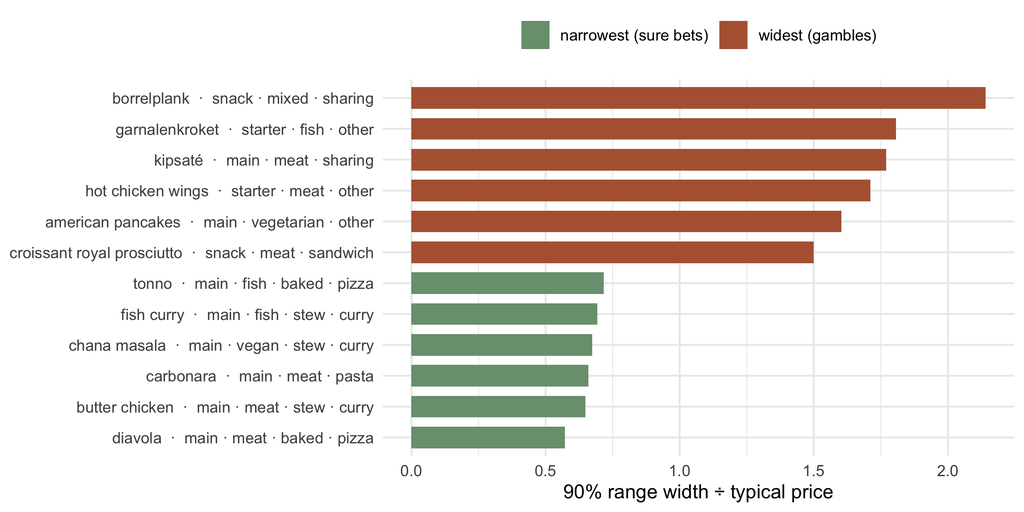

Figure 2: Sure bets vs gambles: the narrowest and widest 90% ranges relative to the typical price, among confident cells with at least 100 dishes. Cuisine-format dishes price tightly; sharing and catch-all formats do not.

```r
ww <- atlas |> filter(tier == "confident", n >= 100) |>
  mutate(relw = (ppi_hi_eur - ppi_lo_eur) / typical_eur,
         label = sprintf("%s  ·  %s", exemplar, sub(" · none", "", cell)))
wide   <- ww |> arrange(desc(relw)) |> head(6) |> mutate(group = "widest (gambles)")
narrow <- ww |> arrange(relw)       |> head(6) |> mutate(group = "narrowest (sure bets)")

ggplot(bind_rows(narrow, wide),
       aes(x = relw, y = reorder(label, relw), fill = group)) +
  geom_col(width = .7) +
  scale_fill_manual(values = c("widest (gambles)" = "#b5623f",
                               "narrowest (sure bets)" = "#7a9e7e"), name = NULL) +
  labs(x = "90% range width ÷ typical price", y = NULL) +
  theme_minimal() + theme(legend.position = "top")
```

**The atlas is a lookup table.** The ten biggest cells, as they ship:

```r
atlas |> arrange(desc(n)) |> head(10) |>
  transmute(cell, exemplar, n, venues,
            typical = sprintf("€%.2f", typical_eur),
            `90% range` = sprintf("€%.1f – €%.1f", ppi_lo_eur, ppi_hi_eur)) |>
  knitr::kable()
```

Table 1: The ten biggest atlas cells. Typical = empirical median; the range is the 90% partially-pooled interval.

| cell | exemplar | n | venues | typical | 90% range |
| --- | --- | --- | --- | --- | --- |
| main · meat · none · plate | kalfslever | 2096 | 449 | €21.70 | €11.0 – €37.1 |
| main · meat · none · sandwich | carpaccio | 1996 | 393 | €12.50 | €5.5 – €21.6 |
| sweet · any · none · other | affogato | 1891 | 518 | €7.50 | €3.0 – €13.0 |
| main · fish · none · plate | dorade | 969 | 339 | €24.50 | €12.0 – €38.6 |
| side · vegan · none · other | friet | 937 | 421 | €5.80 | €2.5 – €9.6 |
| main · meat · grilled · plate | bife de chorizo gr | 909 | 308 | €25.50 | €14.0 – €48.3 |
| main · meat · baked · pizza | diavola | 905 | 112 | €17.50 | €12.3 – €22.3 |
| sweet · any · baked · other | cheesecake | 729 | 321 | €6.00 | €3.0 – €11.3 |
| main · vegetarian · baked · pizza | margherita | 719 | 116 | €16.00 | €9.9 – €22.3 |
| main · vegetarian · none · sandwich | mozzarella di bufala | 648 | 276 | €9.50 | €4.9 – €18.0 |

## The stress-test battery

[output not shown]

## What this is, and what it isn’t

- **No venue is named, structurally.** The atlas aggregates over venues by construction; the per-venue claims that sank the earlier Value Atlas cannot be expressed in it.
- **The exemplar is a label, not a promise.** “Butter chicken” is the most common name inside the meat-curry cell, but actual butter chickens cluster in the upper part of that cell’s range. Read “meat curry, e.g. butter chicken”, never “butter chicken costs €20.80”. (This framing is a known presentation task carried forward from the audit.)
- **Within-cell quality and portion are invisible.** A €12 and a €19 carpaccio may differ in provenance and grams; the atlas sees neither. It prices the *type*, honestly wide.
- **Menu price, not paid price.** No service, no specials, no portion inflation observed.
- **A snapshot.** One city, one month, ~4 in 10 restaurants. The going rates are solid within that scope and dated by construction.

## Lineage

- **Method + brief:** `docs/m5_typical_menus.md` (§4 method, §6 evidence base); audit record `docs/m5_data_audit_findings.md`.
- **Code:** `R/50_dish_atlas_hygiene.R` (cells + hygiene), `R/51_dish_atlas_fit.R` (the nested lme4 fit, the median decision, the K_W=40 blend).
- **Data:** `data/processed/dish_atlas.csv` (199 cells), `dish_atlas_dishes.csv` (32,405 dishes), `dish_atlas_excluded.csv` (the four quarantined package coordinates, with reasons), `dish_atlas_excluded_items.csv` (the item-level curation record, Decision #44).
- **Journal trail:** `2026-06-30_001` (the atlas crystallises), `2026-06-30_002` (the fit + the skew catch + 10-cell hand-validation), `2026-06-30_005/_006` (audit + fixes), `2026-07-07_013` (the package-cell curation), `2026-07-10_001` (the item-level curation).
- **Sources:** restaurant websites (menus), OpenStreetMap (venue universe). All open data. **Snapshot · June 2026.**